# Bus Ridership Prediction in Austin, TX

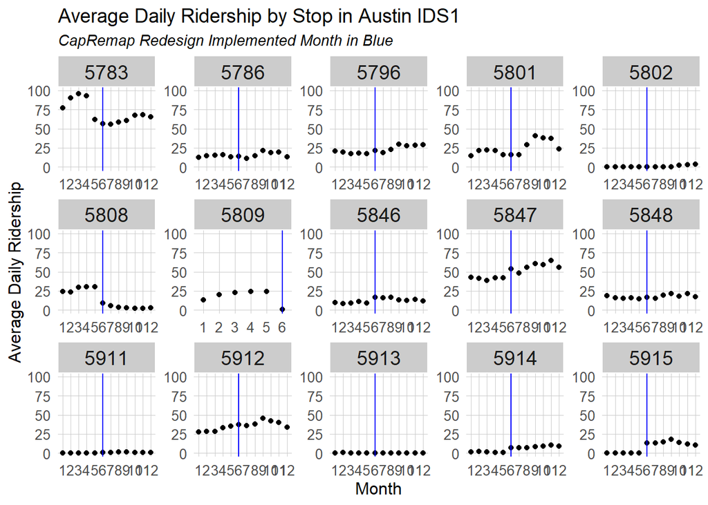

```r
plot.S1.28 <-
  as.data.frame(data.y.18.S1) %>%
  filter(STOP_ID > 5782 & STOP_ID <= 5915) %>%
  group_by(STOP_ID) %>%
    ggplot(aes(x= MONTH_ID, y=AVERAGE_ON, group = 1)) +
      geom_point() +
      plotTheme() +
      facet_wrap(~STOP_ID, scales="free", ncol=5) +
      ylim(0,100) +
      labs(title="Average Daily Ridership by Stop in Austin IDS1",
           subtitle="CapRemap Redesign Implemented Month in Blue", x="Month", y="Average Daily Ridership")+
      geom_vline(xintercept = 6, color = "blue")

plot.S1.28
```

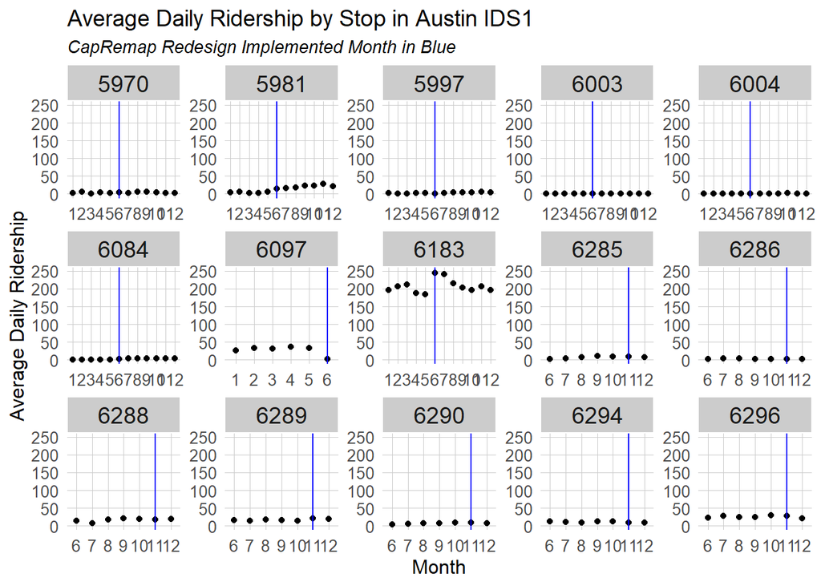

```r
plot.S1.29 <-
  as.data.frame(data.y.18.S1) %>%
  filter(STOP_ID > 5915 & STOP_ID <= 6296) %>%
  group_by(STOP_ID) %>%
    ggplot(aes(x= MONTH_ID, y=AVERAGE_ON, group = 1)) +
      geom_point() +
      plotTheme() +
      facet_wrap(~STOP_ID, scales="free", ncol=5) +
      ylim(0,250) +
      labs(title="Average Daily Ridership by Stop in Austin IDS1",
           subtitle="CapRemap Redesign Implemented Month in Blue", x="Month", y="Average Daily Ridership")+
      geom_vline(xintercept = 6, color = "blue")

plot.S1.29
```

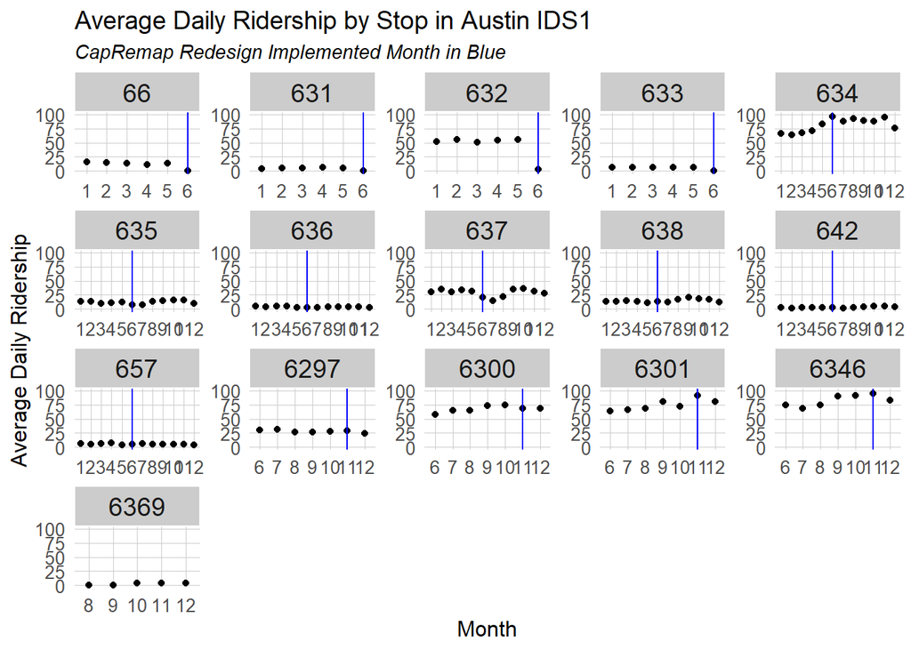

```r
plot.S1.30 <-
  as.data.frame(data.y.18.S1) %>%
  filter(STOP_ID > 6296 | STOP_ID <= 657) %>%
  group_by(STOP_ID) %>%
    ggplot(aes(x= MONTH_ID, y=AVERAGE_ON, group = 1)) +
      geom_point() +
      plotTheme() +
      facet_wrap(~STOP_ID, scales="free", ncol=5) +
      ylim(0,100) +
      labs(title="Average Daily Ridership by Stop in Austin IDS1",
           subtitle="CapRemap Redesign Implemented Month in Blue", x="Month", y="Average Daily Ridership")+
      geom_vline(xintercept = 6, color = "blue")

plot.S1.30
```

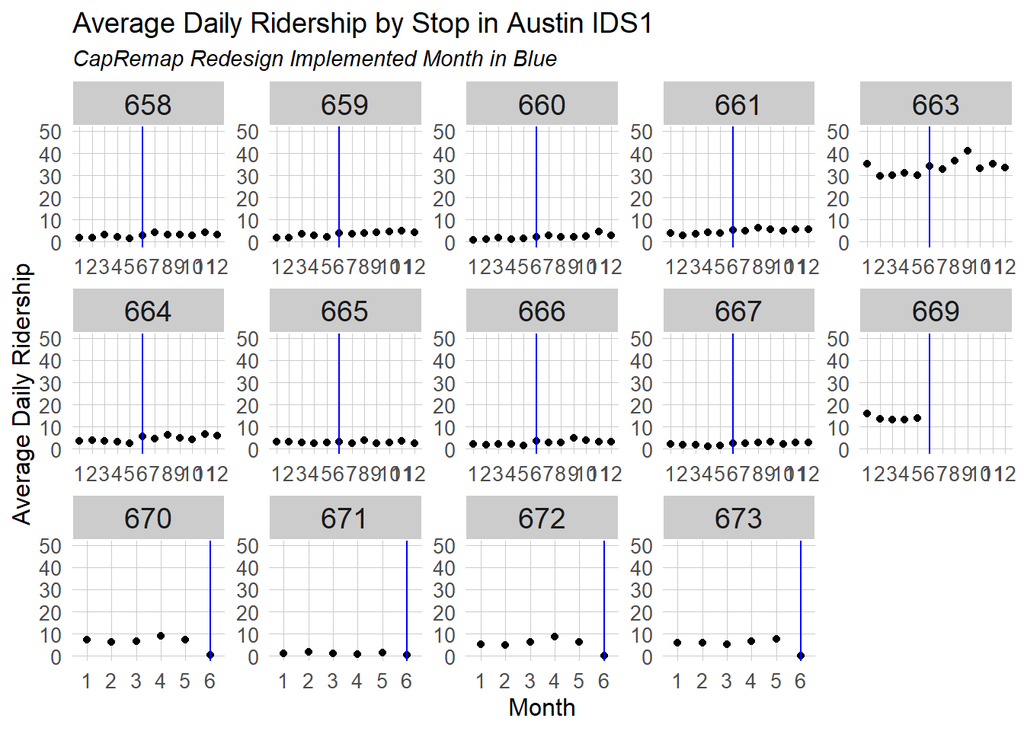

```r
plot.S1.31 <-
  as.data.frame(data.y.18.S1) %>%
  filter(STOP_ID > 657 & STOP_ID <= 673) %>%
  group_by(STOP_ID) %>%
    ggplot(aes(x= MONTH_ID, y=AVERAGE_ON, group = 1)) +
      geom_point() +
      plotTheme() +
      facet_wrap(~STOP_ID, scales="free", ncol=5) +
      ylim(0,50) +
      labs(title="Average Daily Ridership by Stop in Austin IDS1",
           subtitle="CapRemap Redesign Implemented Month in Blue", x="Month", y="Average Daily Ridership")+
      geom_vline(xintercept = 6, color = "blue")

plot.S1.31
```

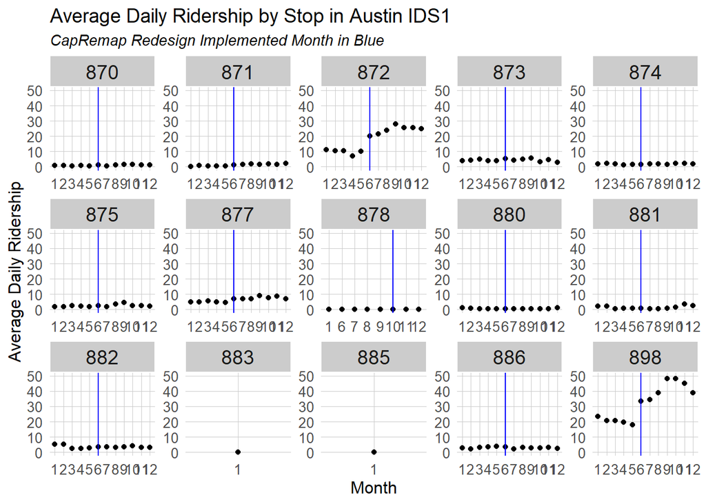

```r
plot.S1.32 <-
  as.data.frame(data.y.18.S1) %>%
  filter(STOP_ID > 673 & STOP_ID <= 898) %>%
  group_by(STOP_ID) %>%
    ggplot(aes(x= MONTH_ID, y=AVERAGE_ON, group = 1)) +
      geom_point() +
      plotTheme() +
      facet_wrap(~STOP_ID, scales="free", ncol=5) +
      ylim(0,50) +
      labs(title="Average Daily Ridership by Stop in Austin IDS1",
           subtitle="CapRemap Redesign Implemented Month in Blue", x="Month", y="Average Daily Ridership")+
      geom_vline(xintercept = 6, color = "blue")

plot.S1.32
```

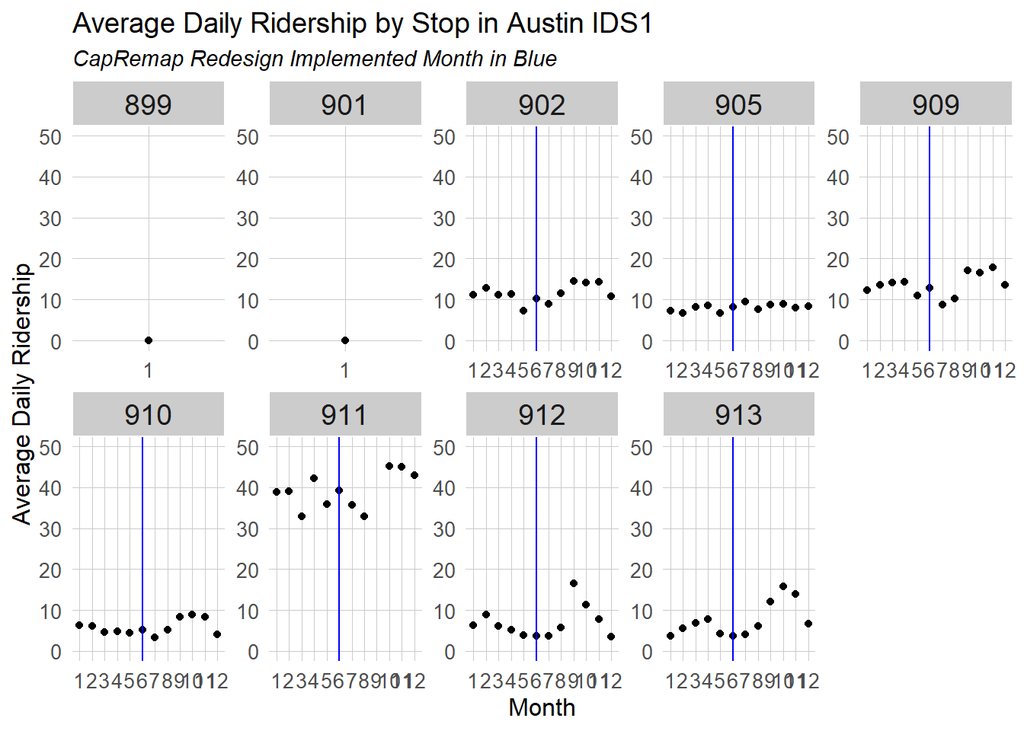

```r
plot.S1.33 <-
  as.data.frame(data.y.18.S1) %>%
  filter(STOP_ID > 898 & STOP_ID <= 913) %>%
  group_by(STOP_ID) %>%
    ggplot(aes(x= MONTH_ID, y=AVERAGE_ON, group = 1)) +
      geom_point() +
      plotTheme() +
      facet_wrap(~STOP_ID, scales="free", ncol=5) +
      ylim(0,50) +
      labs(title="Average Daily Ridership by Stop in Austin IDS1",
           subtitle="CapRemap Redesign Implemented Month in Blue", x="Month", y="Average Daily Ridership")+
      geom_vline(xintercept = 6, color = "blue")

plot.S1.33
```

## Correlation Between Variables Using Aggregate Data

```r
agg <- read.csv('C:/Users/HanyongXu/Documents/Me/grad/Spring_2020/MUSA801/Data/MUSA Data - Stop Ridership Aggregated.csv')
disagg <- read.csv('C:/Users/HanyongXu/Documents/Me/grad/Spring_2020/MUSA801/Data/MUSA Disagregated Data Sample 01-06-2020 to 01-10-2020.csv')
austin <- st_read('https://data.austintexas.gov/api/geospatial/3pzb-6mbr?method=export&format=GeoJSON')

agg = agg %>%
  rename(STOP_ID = ï..STOP_ID,)
disagg = disagg %>%
  rename(LOAD_NUM = ï..LOAD_NUM,)
```

```r
austin <- austin%>%
  st_transform(32140)

#turn dataframe into spacitial object
agg_sf <- agg%>%
  st_as_sf(coords = c("LONGITUDE", "LATITUDE"), crs = 4326)%>%
  st_transform(32140)
```

divide agg_sf data into before and after capremap

```r
agg_before_sf <- agg_sf%>%
  filter(YEAR_ID == 2017 | (YEAR_ID == 2018 & MONTH_ID < 6))%>%
  group_by(STOP_ID)%>%
  summarise(avg_on = mean(AVERAGE_ON),
            avg_trips = mean(TRIPS))%>%
  mutate(ratio = avg_on / avg_trips)
```

```r
agg_after_sf <- agg_sf%>%
  filter(YEAR_ID == 2019 | (YEAR_ID == 2018 & MONTH_ID > 5))%>%
  group_by(STOP_ID)%>%
  summarise(avg_on = mean(AVERAGE_ON),
            avg_trips = mean(TRIPS))%>%
  mutate(ratio = avg_on / avg_trips)
```

scatterplot of ridership vs. number of trips per weekday

```r
Before_scatter <- ggplot()+
  geom_point(data = agg_before_sf, aes(x=avg_trips, y=avg_on, color = STOP_ID))+
  labs(title = "Ridership vs. Number of Trips",
       subtitle = "Before CapRemap",
       xlab = "Average Ridership",
       ylab = "Average Trips")
```

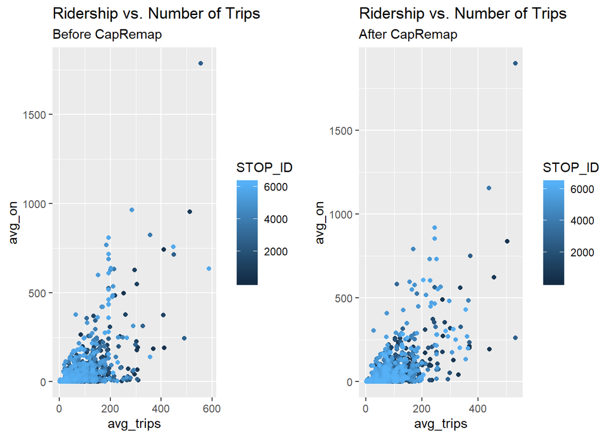

```r
After_scatter <-  ggplot()+
  geom_point(data = agg_after_sf, aes(x=avg_trips, y=avg_on, color = STOP_ID))+
  labs(title = "Ridership vs. Number of Trips",
       subtitle = "After CapRemap",
       xlab = "Average Ridership",
       ylab = "Average Trips")

Scatterplots <- grid.arrange(Before_scatter,After_scatter,ncol = 2)
```

## Mapping the Stops by Ridership Using the Aggregate Data

doesn’t show clear patterns when plotting all the stops

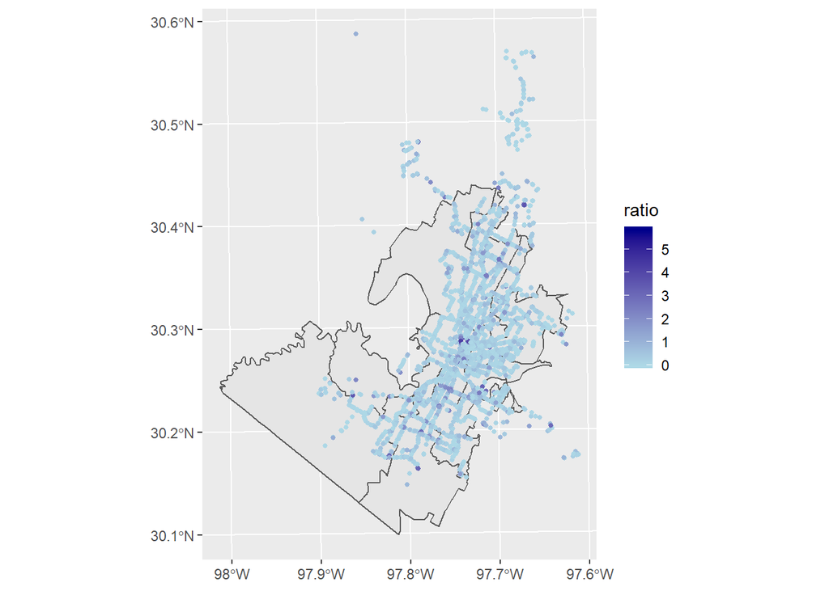

```r
ggplot()+
  geom_sf(data=TrusteeDist)+
  #geom_sf(mapping = aes(), data = austin)+
  geom_sf(mapping = aes(color = ratio), data = agg_before_sf, size = 1)+
  scale_colour_gradient(low = "light blue", high = "darkblue")
```

below 25% as low ridership whereas higher than 75% as high ridership

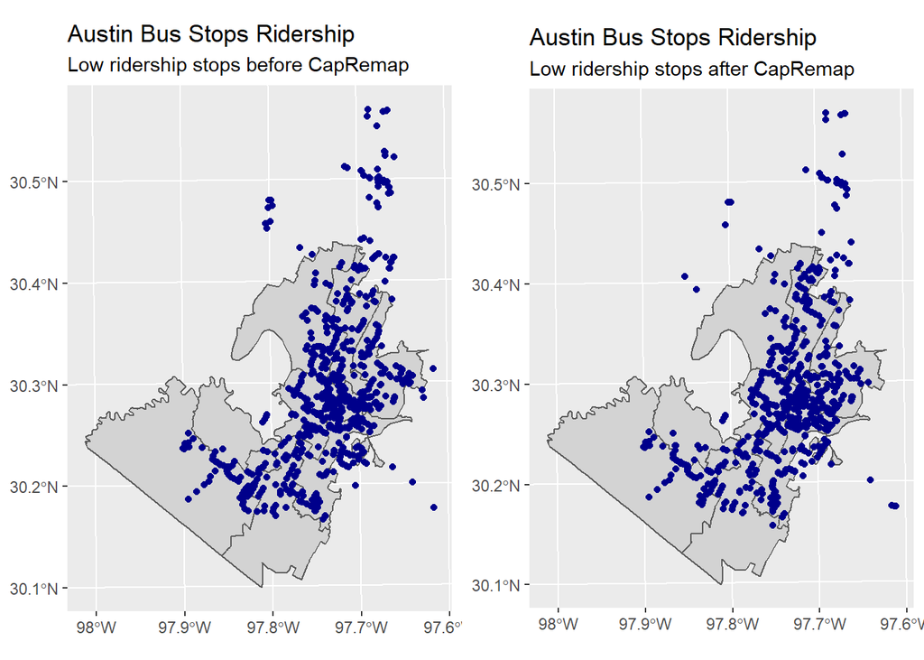

```r
quantile(agg_before_sf$ratio)
quantile(agg_after_sf$ratio)

Low_before <- ggplot(data=TrusteeDist)+
  geom_sf(fill = "light grey")+
  geom_sf(data = subset(agg_before_sf, ratio<0.06505824), color = "darkblue")+
  labs(title = "Austin Bus Stops Ridership",
       subtitle = "Low ridership stops before CapRemap")
Low_after <- ggplot(data=TrusteeDist)+
  geom_sf(fill = "light grey")+
  geom_sf(data = subset(agg_after_sf, ratio<0.03767514), color = "darkblue")+
  labs(title = "Austin Bus Stops Ridership",
       subtitle = "Low ridership stops after CapRemap")

Low_Compare <- grid.arrange(Low_before, Low_after, ncol = 2)
```

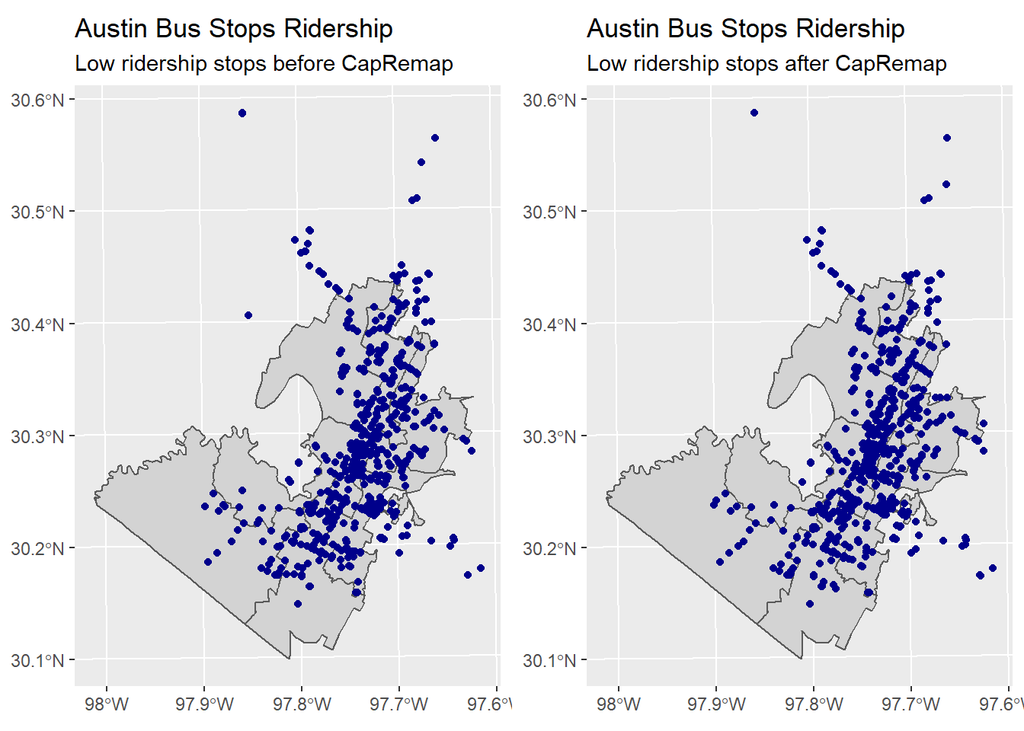

```r
High_before <- ggplot(data=TrusteeDist)+
  geom_sf(fill = "light grey")+
  geom_sf(data = subset(agg_before_sf, ratio>0.43755896), color = "darkblue")+
  labs(title = "Austin Bus Stops Ridership",
       subtitle = "Low ridership stops before CapRemap")

High_after <- ggplot(data=TrusteeDist)+
  geom_sf(fill = "light grey")+
  geom_sf(data = subset(agg_after_sf, ratio>0.41095547), color = "darkblue")+
  labs(title = "Austin Bus Stops Ridership",
       subtitle = "Low ridership stops after CapRemap")

High_Compare <- grid.arrange(High_before, High_after, ncol = 2)
```

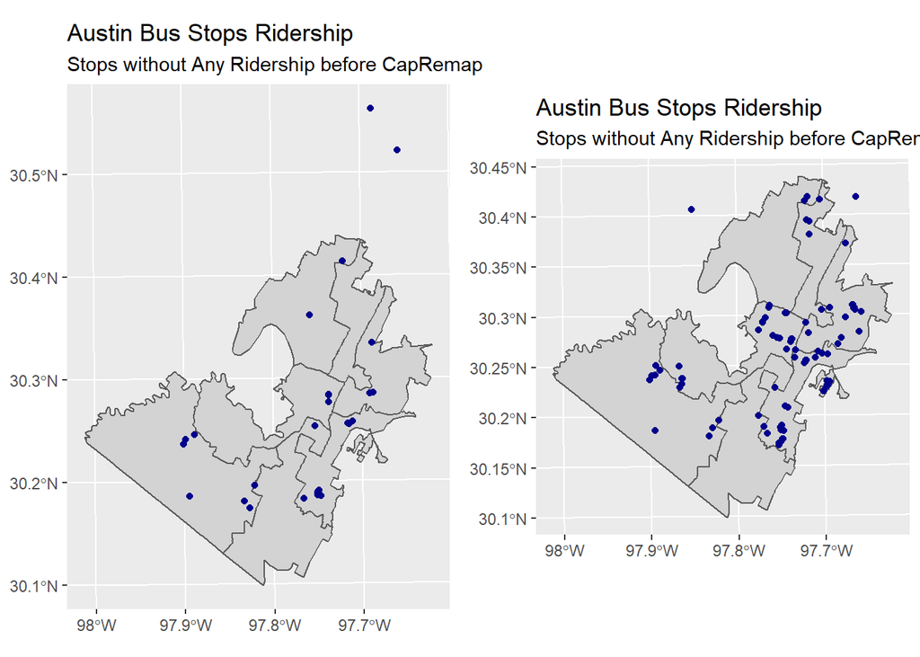

```r
Zero_before <- ggplot(data=TrusteeDist)+
  geom_sf(fill = "light grey")+
  geom_sf(data = subset(agg_before_sf, ratio==0), color = "darkblue")+
  labs(title = "Austin Bus Stops Ridership",
       subtitle = "Stops without Any Ridership before CapRemap")

Zero_after <- ggplot(data=TrusteeDist)+
  geom_sf(fill = "light grey")+
  geom_sf(data = subset(agg_after_sf, ratio==0), color = "darkblue")+
  labs(title = "Austin Bus Stops Ridership",
       subtitle = "Stops without Any Ridership before CapRemap")

Zero_Compare <- grid.arrange(Zero_before, Zero_after, ncol = 2)
```

Mapping ridership in May

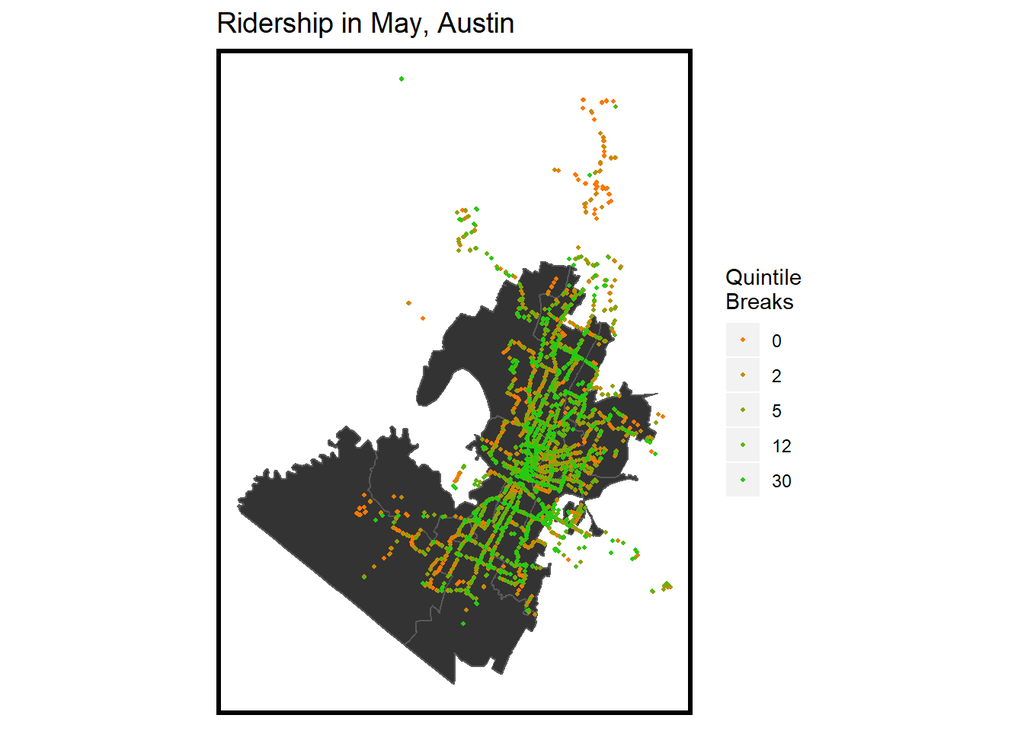

```r
q5 <- function(variable) {as.factor(ntile(variable, 5))}

qBr <- function(df, variable, rnd) {
  if (missing(rnd)) {
    as.character(quantile(round(df[[variable]],0),
                          c(.01,.2,.4,.6,.8), na.rm=T))
  } else if (rnd == FALSE | rnd == F) {
    as.character(formatC(quantile(df[[variable]]), digits = 3),
                 c(.01,.2,.4,.6,.8), na.rm=T)
  }
}

palette5 <- c("#FA7800","#C48C04","#8FA108","#5AB60C","#25CB10")

mapTheme <- function(base_size = 12) {
  theme(
    text = element_text( color = "black"),
    plot.title = element_text(size = 14,colour = "black"),
    plot.subtitle=element_text(face="italic"),
    plot.caption=element_text(hjust=0),
    axis.ticks = element_blank(),
    panel.background = element_blank(),axis.title = element_blank(),
    axis.text = element_blank(),
    axis.title.x = element_blank(),
    axis.title.y = element_blank(),
    panel.grid.minor = element_blank(),
    panel.border = element_rect(colour = "black", fill=NA, size=2)
  )
}
data.y.18.5 <- data.y18 %>%
  subset(data.y18$MONTH_ID == 5)

data.y.18.5.sf <-
  data.y.18.5 %>%
  st_as_sf(coords = c("LONGITUDE", "LATITUDE"), crs = 4326, agr = "constant") %>%
  st_transform(2278)

ggplot()+
  geom_sf(data=TrusteeDist,fill="grey20")+
  geom_sf(data=data.y.18.5.sf,aes(colour=q5(AVERAGE_ON)),show.legend = "point",size = .75)+
  scale_color_manual(values=palette5,
                     labels=qBr(data.y.18.5.sf,"AVERAGE_ON"),
                     name="Quintile\nBreaks")+
  labs(title="Ridership in May, Austin")+
  mapTheme()
```

Mapping ridership in June

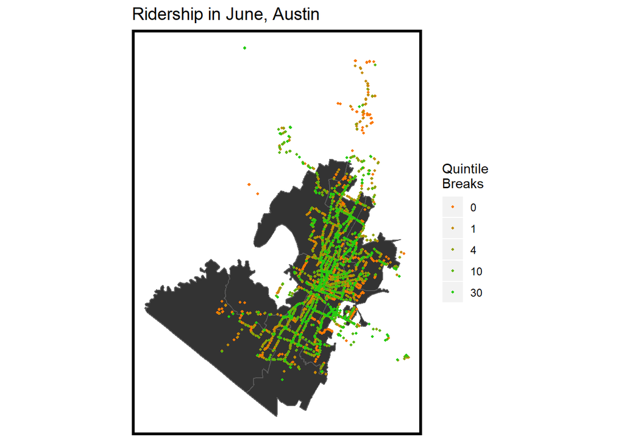

```r
data.y.18.6 <- data.y18 %>%
  subset(data.y18$MONTH_ID == 6)

data.y.18.6.sf <-
  data.y.18.6 %>%
  st_as_sf(coords = c("LONGITUDE", "LATITUDE"), crs = 4326, agr = "constant") %>%
  st_transform(2278)

ggplot()+
  geom_sf(data=TrusteeDist,fill="grey20")+
  geom_sf(data=data.y.18.6.sf,aes(colour=q5(AVERAGE_ON)),show.legend = "point",size = .75)+
  scale_color_manual(values=palette5,
                     labels=qBr(data.y.18.6.sf,"AVERAGE_ON"),
                     name="Quintile\nBreaks")+
  labs(title="Ridership in June, Austin")+
  mapTheme()
```

## Finding the Hotlines and Coldlines Using Disaggregate Data

```r
nhood = st_read('https://data.austintexas.gov/resource/nz5f-3t2e.geojson')
```

overall: find the hot lines by max passenger load

```r
hotlines_x = disagg %>%
  group_by(ROUTE) %>%
  summarise(max_load = max(PSGR_LOAD)) %>%
  arrange(desc(max_load)) %>%
  top_n(5) %>%
  select(ROUTE)
```

find the hot lines by mean passenger load (did not use this for plotting)

```r
disagg %>%
  group_by(ROUTE) %>%
  summarise(mean_load = mean(PSGR_LOAD)) %>%
  arrange(desc(mean_load)) %>%
  top_n(5) %>%
  select(ROUTE)
```

plot it

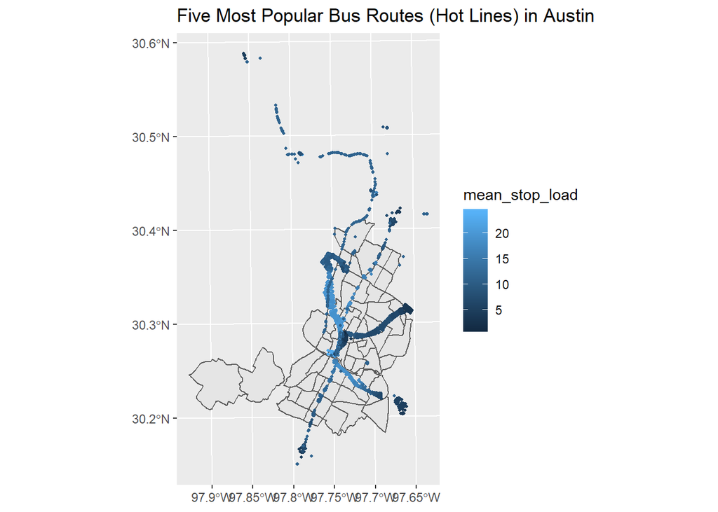

```r
disagg %>%
  filter(ROUTE %in% hotlines_x$ROUTE) %>%
  st_as_sf(coords = c("LONGITUDE", "LATITUDE"), crs = 4326, agr = "constant") %>%
  st_transform(2278) %>%
  group_by(STOP_ID) %>%
  summarise(mean_stop_load = mean(PSGR_LOAD)) %>%
  ggplot() +
  geom_sf(data = nhood) +
  geom_sf( size = 0.8, aes(color = mean_stop_load))+
  labs(title="Five Most Popular Bus Routes (Hot Lines) in Austin")
```

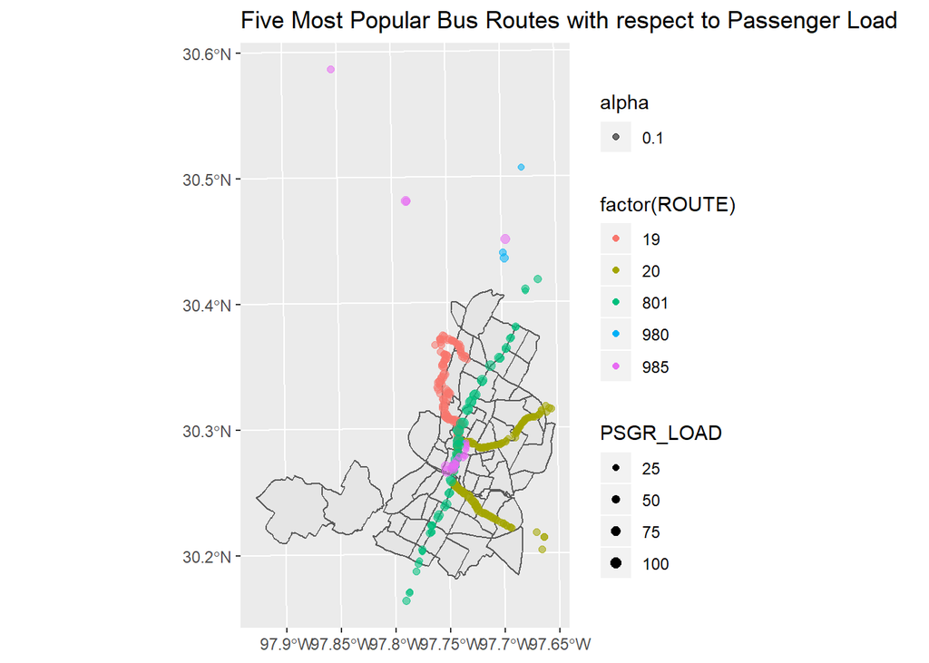

```r
disagg %>%
  filter(ROUTE %in% hotlines_x$ROUTE) %>%
  st_as_sf(coords = c("LONGITUDE", "LATITUDE"), crs = 4326, agr = "constant") %>%
  st_transform(2278) %>%
  group_by(STOP_ID) %>%
  filter(PSGR_LOAD == max(PSGR_LOAD)) %>%
  ggplot() +
  geom_sf(data = nhood) +
  geom_sf(aes(color = factor(ROUTE), size = PSGR_LOAD, alpha = 0.1), show.legend = "point") +
  scale_size(range = c(0.5, 2.5)) +
  labs(title="Five Most Popular Bus Routes with respect to Passenger Load")
```

passenger miles traveled

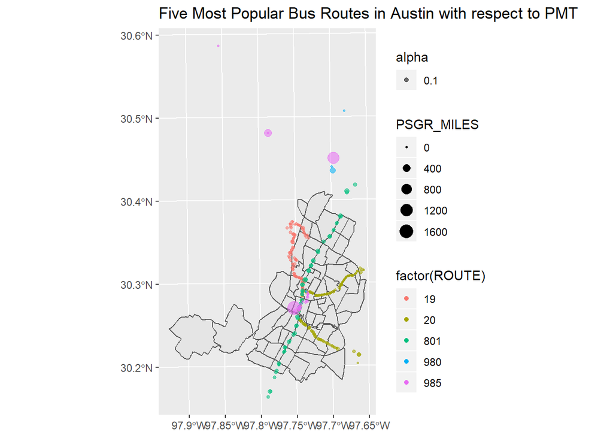

```r
disagg %>%
  filter(ROUTE %in% hotlines_x$ROUTE) %>%
  st_as_sf(coords = c("LONGITUDE", "LATITUDE"), crs = 4326, agr = "constant") %>%
  st_transform(2278) %>%
  group_by(STOP_ID) %>%
  filter(PSGR_LOAD == max(PSGR_LOAD)) %>%
  ggplot() +
  geom_sf(data = nhood) +
  geom_sf(aes(color = factor(ROUTE), size = PSGR_MILES, alpha = 0.1), show.legend = "point") +
  scale_size(range = c(0.5, 5)) +
  labs(title="Five Most Popular Bus Routes in Austin with respect to PMT")
```

use passenger hours to represent durations

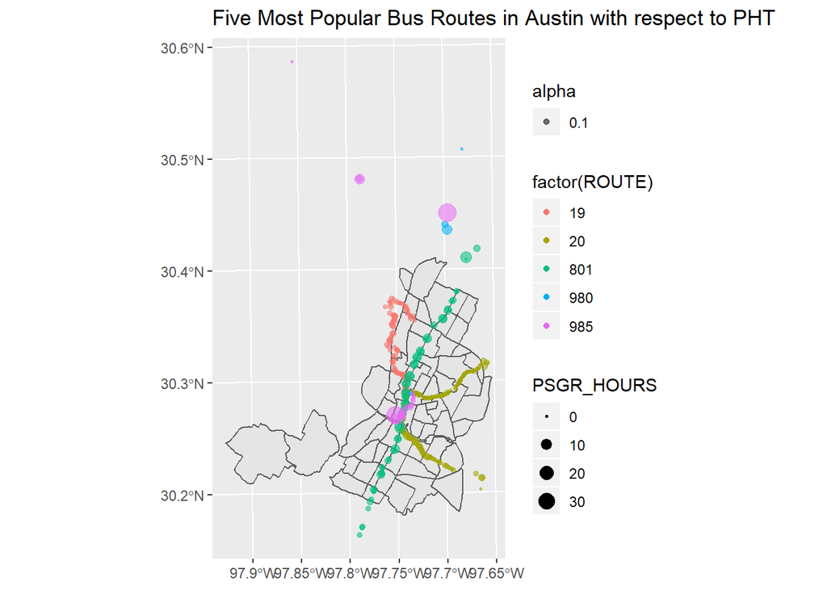

```r
disagg %>%
  filter(ROUTE %in% hotlines_x$ROUTE) %>%
  st_as_sf(coords = c("LONGITUDE", "LATITUDE"), crs = 4326, agr = "constant") %>%
  st_transform(2278) %>%
  group_by(STOP_ID) %>%
  filter(PSGR_LOAD == max(PSGR_LOAD)) %>%
  ggplot() +
  geom_sf(data = nhood) +
  geom_sf(aes(color = factor(ROUTE), size = PSGR_HOURS, alpha = 0.1), show.legend = "point") +
  scale_size(range = c(0.5, 5)) +
  labs(title="Five Most Popular Bus Routes in Austin with respect to PHT")
```

find the cold lines by max passenger load

```r
coldlines_x = disagg %>%
  group_by(ROUTE) %>%
  summarise(max_load = max(PSGR_LOAD)) %>%
  arrange(max_load) %>%
  top_n(-4) %>%
  select(ROUTE)
```

find the cold lines by mean passenger load

```r
disagg %>%
  group_by(ROUTE) %>%
  summarise(mean_load = mean(PSGR_LOAD)) %>%
  arrange(mean_load) %>%
  top_n(-5) %>%
  select(ROUTE)
```

plot it

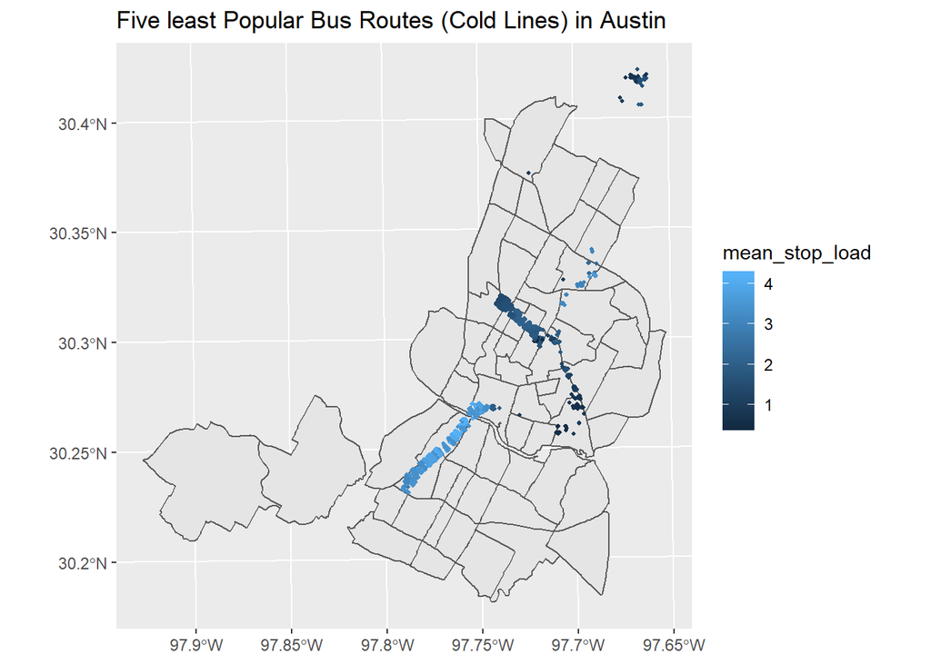

```r
disagg %>%
  filter(ROUTE %in% coldlines_x$ROUTE) %>%
  st_as_sf(coords = c("LONGITUDE", "LATITUDE"), crs = 4326, agr = "constant") %>%
  st_transform(2278) %>%
  group_by(STOP_ID) %>%
  summarise(mean_stop_load = mean(PSGR_LOAD)) %>%
  ggplot() +
  geom_sf(data = nhood) +
  geom_sf(size = 0.8, aes(color = mean_stop_load)) +
  labs(title="Five least Popular Bus Routes (Cold Lines) in Austin")
```

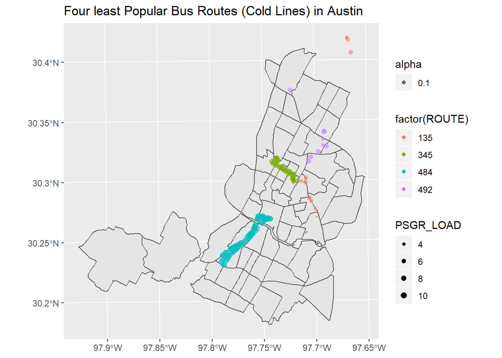

```r
disagg %>%
  filter(ROUTE %in% coldlines_x$ROUTE) %>%
  st_as_sf(coords = c("LONGITUDE", "LATITUDE"), crs = 4326, agr = "constant") %>%
  st_transform(2278) %>%
  group_by(STOP_ID) %>%
  filter(PSGR_LOAD == max(PSGR_LOAD)) %>%
  ggplot() +
  geom_sf(data = nhood) +
  geom_sf(aes(color = factor(ROUTE), size = PSGR_LOAD, alpha = 0.1), show.legend = "point") +
  scale_size(range = c(0.5, 2.5)) +
  labs(title="Four least Popular Bus Routes (Cold Lines) in Austin")
```

passenger miles traveled

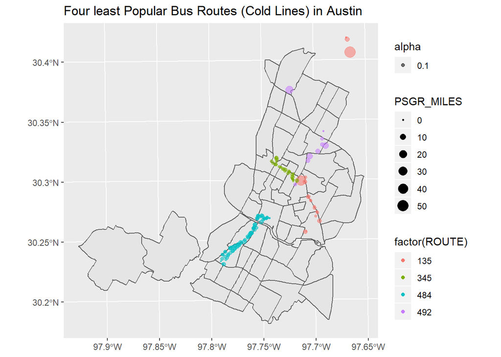

```r
disagg %>%
  filter(ROUTE %in% coldlines_x$ROUTE) %>%
  st_as_sf(coords = c("LONGITUDE", "LATITUDE"), crs = 4326, agr = "constant") %>%
  st_transform(2278) %>%
  group_by(STOP_ID) %>%
  filter(PSGR_LOAD == max(PSGR_LOAD)) %>%
  ggplot() +
  geom_sf(data = nhood) +
  geom_sf(aes(color = factor(ROUTE), size = PSGR_MILES, alpha = 0.1), show.legend = "point") +
  scale_size(range = c(0.5, 5)) +
  labs(title="Four least Popular Bus Routes (Cold Lines) in Austin")
```

use passenger hours to represent durations

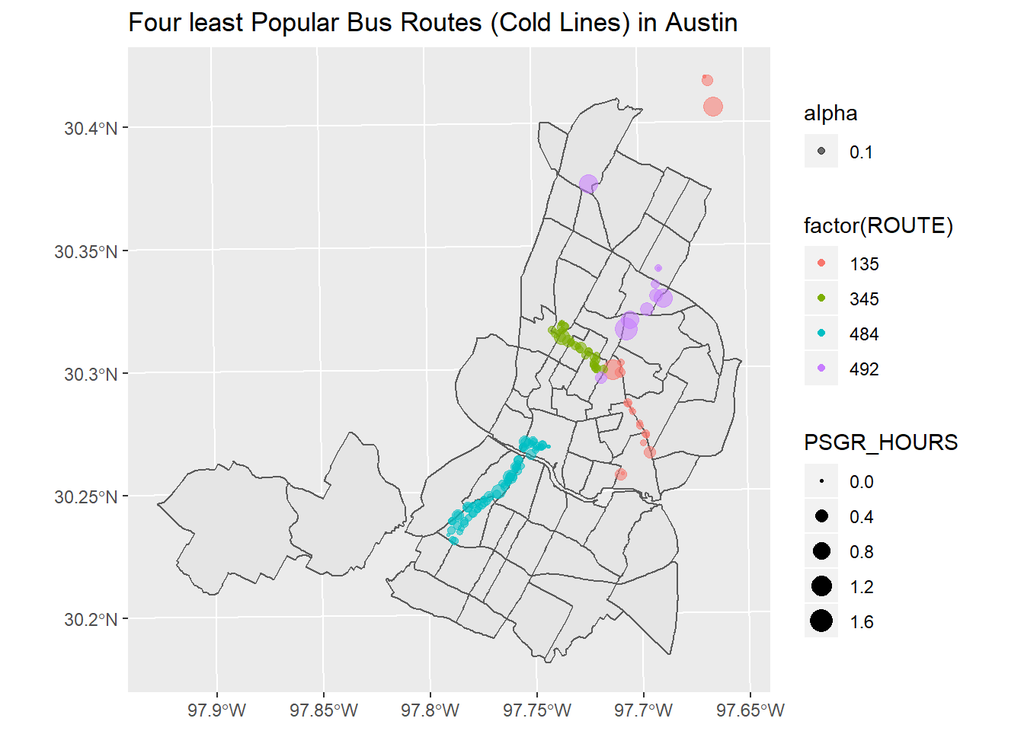

```r
disagg %>%
  filter(ROUTE %in% coldlines_x$ROUTE) %>%
  st_as_sf(coords = c("LONGITUDE", "LATITUDE"), crs = 4326, agr = "constant") %>%
  st_transform(2278) %>%
  group_by(STOP_ID) %>%
  filter(PSGR_LOAD == max(PSGR_LOAD)) %>%
  ggplot() +
  geom_sf(data = nhood) +
  geom_sf(aes(color = factor(ROUTE), size = PSGR_HOURS, alpha = 0.1), show.legend = "point") +
  scale_size(range = c(0.5, 5)) +
  labs(title="Four least Popular Bus Routes (Cold Lines) in Austin")
```

## Find Operation Pattern Using Disaggregate Data

check the highest frequency for hot lines

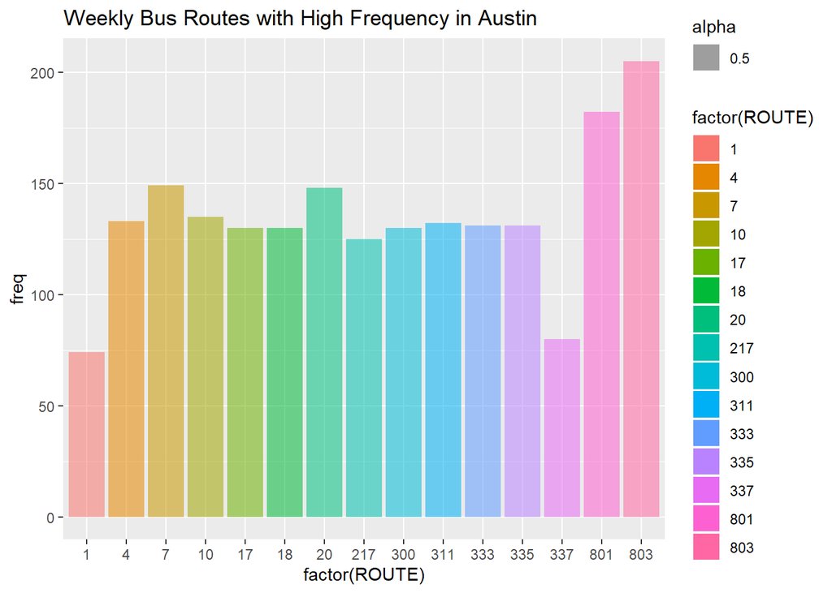

```r
disagg %>%
  group_by(ROUTE) %>%
  summarise(freq = n_distinct(TRIP)) %>%
  arrange(desc(freq))%>%
  top_n(15) %>%
  ggplot() +
  geom_bar(aes(x= factor(ROUTE), y= freq, fill=factor(ROUTE), alpha = 0.5),stat="identity") +
  labs(title="Weekly Bus Routes with High Frequency in Austin")
```

time of large load

```r
disagg_x = disagg %>%
  mutate(datetime = parse_date_time(ACT_STOP_TIME, '%m/%d/%Y %H:%M'),
         interval60 = floor_date(ymd_hms(datetime), unit = "hour"),
         interval15 = floor_date(ymd_hms(datetime), unit = "15 mins"))
```

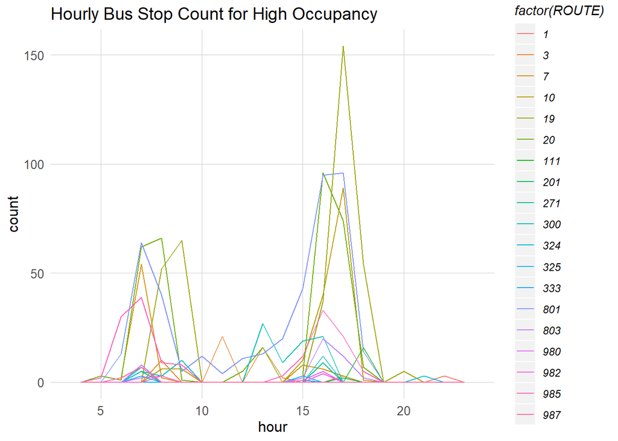

```r
ggplot(disagg_x %>%
         mutate(hour = hour(datetime)) %>%
         filter(PSGR_LOAD > quantile(PSGR_LOAD, 0.997)), aes(hour, color = factor(ROUTE)))+
  geom_freqpoly(binwidth = 1)+
  labs(title="Hourly Bus Stop Count for High Occupancy") +
  plotTheme()
```